# Introducción

El presente proyecto de análisis fue realizado en base a datos de emisiones de CO2 (dióxido de carbono), N20 (óxido nitroso) y CH4 (metano), bajo licencia del Banco Mundial y publicados en [Kaggle](https://www.kaggle.com/datasets/aniruddha1995/firethorn-10-world-co2-emission-analysis) por el usuario Aniruddha Kalblande.

## Sobre el set de datos y el enfoque de análisis

Los datos estudiados comprenden una colección detallada de indicadores medioambientales generados por varios países de todo el mundo, a lo largo de un extenso período histórico de más de 60 años. Gracias a este conjunto de datos, se pueden realizar diferentes análisis desde múltiples perspectivas. Para este en particular nos enfocaremos en los datos más actualizados que se registran, a fines de realizar un estudio descriptivo y gráfico que nos permita obtener conclusiones fundadas sobre la situación medioambiental del mundo y qué curso de acción se debería tomar.

El código y los correspondientes archivos generados y documentación se encuentran disponibles en el repositorio de Github de este proyecto para su descarga y vista en detalle.

## Herramientas utilizadas

RStudio para exploración, limpieza y exportación y Tableau para presentación de gráficas y tablas.

# Organización de datos y exploración

Seteamos el archivo descargado y lo nombramos como “co2_data.csv”. Configuramos el repositorio de GitHub y el directorio de trabajo en la misma ubicación. Una vez listo, desde RStudio, instalaremos y cargaremos la librería ‘tidyverse’.

```r
library(tidyverse)
```

Luego, haremos una primera aproximación a los datos con algunas funciones básicas:

```r
as_tibble(read_csv("co2_data.csv"))
```

```
## # A tibble: 8,251 × 67
##    `Country Name` `Country Code` `Series Name`     `Series Code` `1960 [YR1960]`
##    <chr>          <chr>          <chr>             <chr>         <chr>
##  1 Afghanistan    AFG            Adjusted savings… NY.ADJ.DCO2.… ..
##  2 Afghanistan    AFG            Adjusted savings… NY.ADJ.DCO2.… ..
##  3 Afghanistan    AFG            Agricultural met… EN.ATM.METH.… ..
##  4 Afghanistan    AFG            Agricultural nit… EN.ATM.NOXE.… ..
##  5 Afghanistan    AFG            CO2 emissions (k… EN.ATM.CO2E.… ..
##  6 Afghanistan    AFG            CO2 emissions (k… EN.ATM.CO2E.… ..
##  7 Afghanistan    AFG            CO2 emissions (k… EN.ATM.CO2E.… ..
##  8 Afghanistan    AFG            CO2 emissions (k… EN.ATM.CO2E.… ..
##  9 Afghanistan    AFG            CO2 emissions (m… EN.ATM.CO2E.… ..
## 10 Afghanistan    AFG            CO2 emissions fr… EN.CO2.ETOT.… ..
## # ℹ 8,241 more rows
## # ℹ 62 more variables: `1961 [YR1961]` <chr>, `1962 [YR1962]` <chr>,
## #   `1963 [YR1963]` <chr>, `1964 [YR1964]` <chr>, `1965 [YR1965]` <chr>,
## #   `1966 [YR1966]` <chr>, `1967 [YR1967]` <chr>, `1968 [YR1968]` <chr>,
## #   `1969 [YR1969]` <chr>, `1970 [YR1970]` <chr>, `1971 [YR1971]` <chr>,
## #   `1972 [YR1972]` <chr>, `1973 [YR1973]` <chr>, `1974 [YR1974]` <chr>,
## #   `1975 [YR1975]` <chr>, `1976 [YR1976]` <chr>, `1977 [YR1977]` <chr>, …
```

```r
str(read_csv("co2_data.csv"))
```

```
## spc_tbl_ [8,251 × 67] (S3: spec_tbl_df/tbl_df/tbl/data.frame)
##  $ Country Name : chr [1:8251] "Afghanistan" "Afghanistan" "Afghanistan" "Afghanistan" ...
##  $ Country Code : chr [1:8251] "AFG" "AFG" "AFG" "AFG" ...
##  $ Series Name  : chr [1:8251] "Adjusted savings: carbon dioxide damage (% of GNI)" "Adjusted savings: carbon dioxide damage (current US$)" "Agricultural methane emissions (thousand metric tons of CO2 equivalent)" "Agricultural nitrous oxide emissions (thousand metric tons of CO2 equivalent)" ...
##  $ Series Code  : chr [1:8251] "NY.ADJ.DCO2.GN.ZS" "NY.ADJ.DCO2.CD" "EN.ATM.METH.AG.KT.CE" "EN.ATM.NOXE.AG.KT.CE" ...
##  $ 1960 [YR1960]: chr [1:8251] ".." ".." ".." ".." ...
##  $ 1961 [YR1961]: chr [1:8251] ".." ".." ".." ".." ...
##  $ 1962 [YR1962]: chr [1:8251] ".." ".." ".." ".." ...
##  $ 1963 [YR1963]: chr [1:8251] ".." ".." ".." ".." ...
##  $ 1964 [YR1964]: chr [1:8251] ".." ".." ".." ".." ...
##  $ 1965 [YR1965]: chr [1:8251] ".." ".." ".." ".." ...
##  $ 1966 [YR1966]: chr [1:8251] ".." ".." ".." ".." ...
##  $ 1967 [YR1967]: chr [1:8251] ".." ".." ".." ".." ...
##  $ 1968 [YR1968]: chr [1:8251] ".." ".." ".." ".." ...
##  $ 1969 [YR1969]: chr [1:8251] ".." ".." ".." ".." ...
##  $ 1970 [YR1970]: chr [1:8251] "0.2479932671915" "4425302.03573394" ".." ".." ...
##  $ 1971 [YR1971]: chr [1:8251] "0.288137087135604" "5384955.56382029" ".." ".." ...
##  $ 1972 [YR1972]: chr [1:8251] "0.285676732706283" "4659698.72095854" ".." ".." ...
##  $ 1973 [YR1973]: chr [1:8251] "0.304645891537907" "5395610.63255642" ".." ".." ...
##  $ 1974 [YR1974]: chr [1:8251] "0.319321280310792" "7032164.21693166" ".." ".." ...
##  $ 1975 [YR1975]: chr [1:8251] "0.358075043279523" "8657458.82497619" ".." ".." ...
##  $ 1976 [YR1976]: chr [1:8251] "0.334527205091101" "8734877.19206038" ".." ".." ...
##  $ 1977 [YR1977]: chr [1:8251] "0.378393235484575" "11419066.6711941" ".." ".." ...
##  $ 1978 [YR1978]: chr [1:8251] "0.335005742513392" "11293415.5638028" ".." ".." ...
##  $ 1979 [YR1979]: chr [1:8251] "0.344541955196129" "13009021.473817" ".." ".." ...
##  $ 1980 [YR1980]: chr [1:8251] "0.306189911472487" "11379711.0968171" ".." ".." ...
##  $ 1981 [YR1981]: chr [1:8251] "0.404177901228618" "14354438.7726524" ".." ".." ...
##  $ 1982 [YR1982]: chr [1:8251] ".." "16470068.9004485" ".." ".." ...
##  $ 1983 [YR1983]: chr [1:8251] ".." "21032261.0848859" ".." ".." ...
##  $ 1984 [YR1984]: chr [1:8251] ".." "25041617.4397218" ".." ".." ...
##  $ 1985 [YR1985]: chr [1:8251] ".." "32745539.3526144" ".." ".." ...
##  $ 1986 [YR1986]: chr [1:8251] ".." "30575972.0174744" ".." ".." ...
##  $ 1987 [YR1987]: chr [1:8251] ".." "31871213.5625408" ".." ".." ...
##  $ 1988 [YR1988]: chr [1:8251] ".." "30963769.1531301" ".." ".." ...
##  $ 1989 [YR1989]: chr [1:8251] ".." "31821964.3791876" ".." ".." ...
##  $ 1990 [YR1990]: chr [1:8251] ".." "35990789.6764766" "5361.61" "2705.2738" ...
##  $ 1991 [YR1991]: chr [1:8251] ".." "35244502.1600685" "5603.93" "2786.5384" ...
##  $ 1992 [YR1992]: chr [1:8251] ".." "19296048.1118209" "5668.51" "2735.0142" ...
##  $ 1993 [YR1993]: chr [1:8251] ".." "19173399.2334259" "5712.9575" "2767.526" ...
##  $ 1994 [YR1994]: chr [1:8251] ".." "19176964.8576402" "5925.005" "2592.9576" ...
```

[output cut: 84 more lines]

```
##   ..   `2010 [YR2010]` = col_character(),
##   ..   `2011 [YR2011]` = col_character(),
##   ..   `2012 [YR2012]` = col_character(),
##   ..   `2013 [YR2013]` = col_character(),
##   ..   `2014 [YR2014]` = col_character(),
##   ..   `2015 [YR2015]` = col_character(),
##   ..   `2016 [YR2016]` = col_character(),
##   ..   `2017 [YR2017]` = col_character(),
##   ..   `2018 [YR2018]` = col_character(),
##   ..   `2019 [YR2019]` = col_character(),
##   ..   `2020 [YR2020]` = col_character(),
##   ..   `2021 [YR2021]` = col_character(),
##   ..   `2022 [YR2022]` = col_character()
##   .. )
##  - attr(*, "problems")=<externalptr>
```

```r
col(read_csv("co2_data.csv"))
```

[output not shown]

[output cut: 8944 more lines]

```r
print(read_csv("co2_data.csv"))
```

```
## # A tibble: 8,251 × 67
##    `Country Name` `Country Code` `Series Name`     `Series Code` `1960 [YR1960]`
##    <chr>          <chr>          <chr>             <chr>         <chr>
##  1 Afghanistan    AFG            Adjusted savings… NY.ADJ.DCO2.… ..
##  2 Afghanistan    AFG            Adjusted savings… NY.ADJ.DCO2.… ..
##  3 Afghanistan    AFG            Agricultural met… EN.ATM.METH.… ..
##  4 Afghanistan    AFG            Agricultural nit… EN.ATM.NOXE.… ..
##  5 Afghanistan    AFG            CO2 emissions (k… EN.ATM.CO2E.… ..
##  6 Afghanistan    AFG            CO2 emissions (k… EN.ATM.CO2E.… ..
##  7 Afghanistan    AFG            CO2 emissions (k… EN.ATM.CO2E.… ..
##  8 Afghanistan    AFG            CO2 emissions (k… EN.ATM.CO2E.… ..
##  9 Afghanistan    AFG            CO2 emissions (m… EN.ATM.CO2E.… ..
## 10 Afghanistan    AFG            CO2 emissions fr… EN.CO2.ETOT.… ..
## # ℹ 8,241 more rows
## # ℹ 62 more variables: `1961 [YR1961]` <chr>, `1962 [YR1962]` <chr>,
## #   `1963 [YR1963]` <chr>, `1964 [YR1964]` <chr>, `1965 [YR1965]` <chr>,
## #   `1966 [YR1966]` <chr>, `1967 [YR1967]` <chr>, `1968 [YR1968]` <chr>,
## #   `1969 [YR1969]` <chr>, `1970 [YR1970]` <chr>, `1971 [YR1971]` <chr>,
## #   `1972 [YR1972]` <chr>, `1973 [YR1973]` <chr>, `1974 [YR1974]` <chr>,
## #   `1975 [YR1975]` <chr>, `1976 [YR1976]` <chr>, `1977 [YR1977]` <chr>, …
```

El set comprende una gran cantidad de campos. Muchos de ellos clasificados en subcategorías.

Se observa también una gran presencia de incompletos (…) que, por ahora, no borraremos hasta tener un conocimiento más exacto de la estructura del set de datos.

Notamos también la presencia de números de gran magnitud que, por lo general, RStudio suele formatear como números en notación científica. Para que esto no suceda y la lectura sea fácil, preparamos el programa con:

```r
options(scipen = 999)
```

Comenzamos a trabajar alojando el set de datos inicial en una variable.

```r
co2_df <- read.csv("co2_data.csv")
```

Como punto de partida, cambiamos los nombres de las columnas y formateamos sus datos como números.

```r
co2_df <- co2_df %>%
  rename(Pais=Country.Name,
         Cod_Pais=Country.Code,
         Serie=Series.Name,
         Cod_Serie=Series.Code,
         Año_1960=X1960..YR1960.,
         Año_1961=X1961..YR1961.,
         Año_1962=X1962..YR1962.,
         Año_1963=X1963..YR1963.,
         Año_1964=X1964..YR1964.,
         Año_1965=X1965..YR1965.,
         Año_1966=X1966..YR1966.,
         Año_1967=X1967..YR1967.,
         Año_1968=X1968..YR1968.,
         Año_1969=X1969..YR1969.,
         Año_1970=X1970..YR1970.,
         Año_1971=X1971..YR1971.,
         Año_1972=X1972..YR1972.,
         Año_1973=X1973..YR1973.,
         Año_1974=X1974..YR1974.,
         Año_1975=X1975..YR1975.,
         Año_1976=X1976..YR1976.,
         Año_1977=X1977..YR1977.,
         Año_1978=X1978..YR1978.,
         Año_1979=X1979..YR1979.,
         Año_1980=X1980..YR1980.,
         Año_1981=X1981..YR1981.,
         Año_1982=X1982..YR1982.,
         Año_1983=X1983..YR1983.,
         Año_1984=X1984..YR1984.,
         Año_1985=X1985..YR1985.,
         Año_1986=X1986..YR1986.,
         Año_1987=X1987..YR1987.,
         Año_1988=X1988..YR1988.,
         Año_1989=X1989..YR1989.,
         Año_1990=X1990..YR1990.,
         Año_1991=X1991..YR1991.,
         Año_1992=X1992..YR1992.,
         Año_1993=X1993..YR1993.,
         Año_1994=X1994..YR1994.,
         Año_1995=X1995..YR1995.,
         Año_1996=X1996..YR1996.,
         Año_1997=X1997..YR1997.,
         Año_1998=X1998..YR1998.,
         Año_1999=X1999..YR1999.,
         Año_2000=X2000..YR2000.,
         Año_2001=X2001..YR2001.,
         Año_2002=X2002..YR2002.,
         Año_2003=X2003..YR2003.,
         Año_2004=X2004..YR2004.,
         Año_2005=X2005..YR2005.,
         Año_2006=X2006..YR2006.,
         Año_2007=X2007..YR2007.,
         Año_2008=X2008..YR2008.,
         Año_2009=X2009..YR2009.,
         Año_2010=X2010..YR2010.,
         Año_2011=X2011..YR2011.,
         Año_2012=X2012..YR2012.,
         Año_2013=X2013..YR2013.,
         Año_2014=X2014..YR2014.,
         Año_2015=X2015..YR2015.,
         Año_2016=X2016..YR2016.,
         Año_2017=X2017..YR2017.,
         Año_2018=X2018..YR2018.,
         Año_2019=X2019..YR2019.,
         Año_2020=X2020..YR2020.,
         Año_2021=X2021..YR2021.,
         Año_2022=X2022..YR2022.) %>%
  mutate(Año_1960=as.numeric(Año_1960),
         Año_1960=as.numeric(Año_1960),
         Año_1961=as.numeric(Año_1961),
         Año_1962=as.numeric(Año_1962),
         Año_1963=as.numeric(Año_1963),
         Año_1964=as.numeric(Año_1964),
         Año_1965=as.numeric(Año_1965),
         Año_1966=as.numeric(Año_1966),
         Año_1967=as.numeric(Año_1967),
         Año_1968=as.numeric(Año_1968),
         Año_1969=as.numeric(Año_1969),
         Año_1970=as.numeric(Año_1970),
         Año_1971=as.numeric(Año_1971),
         Año_1972=as.numeric(Año_1972),
         Año_1973=as.numeric(Año_1973),
         Año_1974=as.numeric(Año_1974),
         Año_1975=as.numeric(Año_1975),
         Año_1976=as.numeric(Año_1976),
         Año_1977=as.numeric(Año_1977),
         Año_1978=as.numeric(Año_1978),
         Año_1979=as.numeric(Año_1979),
         Año_1980=as.numeric(Año_1980),
         Año_1981=as.numeric(Año_1981),
         Año_1982=as.numeric(Año_1982),
         Año_1983=as.numeric(Año_1983),
         Año_1984=as.numeric(Año_1984),
         Año_1985=as.numeric(Año_1985),
         Año_1986=as.numeric(Año_1986),
         Año_1987=as.numeric(Año_1987),
         Año_1988=as.numeric(Año_1988),
         Año_1989=as.numeric(Año_1989),
         Año_1990=as.numeric(Año_1990),
         Año_1991=as.numeric(Año_1991),
         Año_1992=as.numeric(Año_1992),
         Año_1993=as.numeric(Año_1993),
         Año_1994=as.numeric(Año_1994),
         Año_1995=as.numeric(Año_1995),
         Año_1996=as.numeric(Año_1996),
         Año_1997=as.numeric(Año_1997),
         Año_1998=as.numeric(Año_1998),
         Año_1999=as.numeric(Año_1999),
         Año_2000=as.numeric(Año_2000),
         Año_2001=as.numeric(Año_2001),
         Año_2002=as.numeric(Año_2002),
         Año_2003=as.numeric(Año_2003),
         Año_2004=as.numeric(Año_2004),
         Año_2005=as.numeric(Año_2005),
         Año_2006=as.numeric(Año_2006),
         Año_2007=as.numeric(Año_2007),
         Año_2008=as.numeric(Año_2008),
         Año_2009=as.numeric(Año_2009),
         Año_2010=as.numeric(Año_2010),
         Año_2011=as.numeric(Año_2011),
         Año_2012=as.numeric(Año_2012),
         Año_2013=as.numeric(Año_2013),
         Año_2014=as.numeric(Año_2014),
         Año_2015=as.numeric(Año_2015),
         Año_2016=as.numeric(Año_2016),
         Año_2017=as.numeric(Año_2017),
         Año_2018=as.numeric(Año_2018),
         Año_2019=as.numeric(Año_2019),
         Año_2020=as.numeric(Año_2020),
         Año_2021=as.numeric(Año_2021),
         Año_2022=as.numeric(Año_2022))
as_tibble(co2_df)
```

```
## # A tibble: 8,251 × 67
##    Pais    Cod_Pais Serie Cod_Serie Año_1960 Año_1961 Año_1962 Año_1963 Año_1964
##    <chr>   <chr>    <chr> <chr>        <dbl>    <dbl>    <dbl>    <dbl>    <dbl>
##  1 Afghan… AFG      Adju… NY.ADJ.D…       NA       NA       NA       NA       NA
##  2 Afghan… AFG      Adju… NY.ADJ.D…       NA       NA       NA       NA       NA
##  3 Afghan… AFG      Agri… EN.ATM.M…       NA       NA       NA       NA       NA
##  4 Afghan… AFG      Agri… EN.ATM.N…       NA       NA       NA       NA       NA
##  5 Afghan… AFG      CO2 … EN.ATM.C…       NA       NA       NA       NA       NA
##  6 Afghan… AFG      CO2 … EN.ATM.C…       NA       NA       NA       NA       NA
##  7 Afghan… AFG      CO2 … EN.ATM.C…       NA       NA       NA       NA       NA
##  8 Afghan… AFG      CO2 … EN.ATM.C…       NA       NA       NA       NA       NA
##  9 Afghan… AFG      CO2 … EN.ATM.C…       NA       NA       NA       NA       NA
## 10 Afghan… AFG      CO2 … EN.CO2.E…       NA       NA       NA       NA       NA
## # ℹ 8,241 more rows
## # ℹ 58 more variables: Año_1965 <dbl>, Año_1966 <dbl>, Año_1967 <dbl>,
## #   Año_1968 <dbl>, Año_1969 <dbl>, Año_1970 <dbl>, Año_1971 <dbl>,
## #   Año_1972 <dbl>, Año_1973 <dbl>, Año_1974 <dbl>, Año_1975 <dbl>,
## #   Año_1976 <dbl>, Año_1977 <dbl>, Año_1978 <dbl>, Año_1979 <dbl>,
## #   Año_1980 <dbl>, Año_1981 <dbl>, Año_1982 <dbl>, Año_1983 <dbl>,
## #   Año_1984 <dbl>, Año_1985 <dbl>, Año_1986 <dbl>, Año_1987 <dbl>, …
```

Ahora contamos con un set de datos formateado con el cual, si quisiéramos, podríamos analizar de diferentes formas en función de la información que querramos obtener del mismo.

Para este análisis, nos interesa saber qué datos se encuentran completos para cada país en el año 2020 (el último año que registra datos en el set) y con ello en mente continuamos explorando, prestando atención a algunas de las subcategorías que se presentan en la columna “Serie”.

Vemos que una buena opción para esto, son los datos categorizados como:

- CO2 emissions (kt), es decir, las emisiones de dióxido de carbono en kilotoneladas
- Methane emissions (kt of CO2 equivalent), que representa las emisiones de metano en kilotoneladas equivalentes de CO2
- Nitrous oxide emissions (thousand metric tons of CO2 equivalent), que son las emisiones de óxido nitroso en toneladas de CO2 equivalentes.

Creamos entonces data frames nuevos a partir del original, filtrando por categorías:

```r
co2_emisiones_2020 <- co2_df %>%
  filter(Serie == "CO2 emissions (kt)") %>%
  select(Pais, Año_2020)

as_tibble(co2_emisiones_2020)
```

```
## # A tibble: 266 × 2
##    Pais                Año_2020
##    <chr>                  <dbl>
##  1 Afghanistan            8709.
##  2 Albania                4383.
##  3 Algeria              161563
##  4 American Samoa           NA
##  5 Andorra                 449.
##  6 Angola                19814.
##  7 Antigua and Barbuda     475.
##  8 Argentina            154536.
##  9 Armenia                6747.
## 10 Aruba                    NA
## # ℹ 256 more rows
```

```r
ch4_2020 <- co2_df %>%
  filter(Serie == "Methane emissions (kt of CO2 equivalent)") %>%
  select(Pais, Año_2020)

as_tibble(ch4_2020)
```

```
## # A tibble: 266 × 2
##    Pais                Año_2020
##    <chr>                  <dbl>
##  1 Afghanistan          16222.
##  2 Albania               2692.
##  3 Algeria              86544.
##  4 American Samoa          NA
##  5 Andorra                 53.6
##  6 Angola               32703.
##  7 Antigua and Barbuda    205.
##  8 Argentina           131036.
##  9 Armenia               2320.
## 10 Aruba                   NA
## # ℹ 256 more rows
```

```r
no2_2020 <- co2_df %>%
  filter(Serie == "Nitrous oxide emissions (thousand metric tons of CO2 equivalent)") %>%
  select(Pais, Año_2020)

as_tibble(no2_2020)
```

```
## # A tibble: 266 × 2
##    Pais                Año_2020
##    <chr>                  <dbl>
##  1 Afghanistan          4863.
##  2 Albania              1015.
##  3 Algeria             12579.
##  4 American Samoa         NA
##  5 Andorra                 1.76
##  6 Angola              17758.
##  7 Antigua and Barbuda    11.8
##  8 Argentina           51061.
##  9 Armenia              1174.
## 10 Aruba                  NA
## # ℹ 256 more rows
```

Para estos tres casos vemos que los data frames resultantes se ven bastante sólidos y completos en su generalidad, a excepción de algunos casos faltantes, que comprobaremos más adelante.

Otras categorías que exploramos son:

- CO2 emissions from electricity and heat production, total (% of total fuel combustion), es decir emisiones de dióxido de carbono provenientes de la generación de electricidad y de calor.
- CO2 emissions from gaseous fuel consumption (% of total), que representa al porcentaje del total de emisiones de CO2 provenientes de consumo de combustible gaseoso.
- CO2 emissions from liquid fuel consumption (kt), que serían las emisiones de CO2 provenientes del consumo de combustible líquido.

Sin embargo, al hacer los dataframes veremos que en su totalidad los datos se encuentran incompletos. Esto puede comprobarse en el script disponible en el repositorio del proyecto.

Sabiendo esto, entonces, continuamos nuestro proceso poniendo el foco en la información con la que sí contamos, la cual en su mayoría se encuentra completa, pero presenta algunas faltas en forma de NA (no disponibles.)

Evaluamos la posibilidad de prescindir de estos “no disponibles” para nuestro análisis. Y lo hacemos comparando entre los tres nuevos data frames; buscando si los datos faltantes pertenecen a los mismos países.

El siguiente código, nos devuelve los índices de los países con datos incompletos.

```r
which(is.na(no2_2020$Año_2020))
```

```
##  [1]   4  10  22  28  37  40  51  66  70  76  78  80  87  95 106 118 131 141 147
## [20] 159 165 173 184 201 213 214 253
```

```r
which(is.na(ch4_2020$Año_2020))
```

```
##  [1]   4  10  22  28  37  40  51  66  70  76  78  80  87  95 106 118 131 141 147
## [20] 159 165 173 184 201 213 214 253
```

```r
which(is.na(co2_emisiones_2020$Año_2020))
```

```
##  [1]   4  10  22  28  37  40  51  66  70  76  78  80  87  95 106 118 131 141 147
## [20] 159 165 173 184 201 213 214 253
```

Para saber a qué país pertenece cada índice, alojamos los datos en variables y escribimos:

```r
co2_nas <- co2_emisiones_2020$Pais[which(is.na(co2_emisiones_2020$Año_2020))]
no2_nas <- no2_2020$Pais[which(is.na(no2_2020$Año_2020))]
ch4_nas <- ch4_2020$Pais[which(is.na(ch4_2020$Año_2020))]

print(co2_nas)
```

```
##  [1] "American Samoa"            "Aruba"
##  [3] "Bermuda"                   "British Virgin Islands"
##  [5] "Cayman Islands"            "Channel Islands"
##  [7] "Curacao"                   "Faroe Islands"
##  [9] "French Polynesia"          "Gibraltar"
## [11] "Greenland"                 "Guam"
## [13] "Hong Kong SAR, China"      "Isle of Man"
## [15] "Kosovo"                    "Macao SAR, China"
## [17] "Monaco"                    "New Caledonia"
## [19] "Northern Mariana Islands"  "Puerto Rico"
## [21] "San Marino"                "Sint Maarten (Dutch part)"
## [23] "St. Martin (French part)"  "Turks and Caicos Islands"
## [25] "Virgin Islands (U.S.)"     "West Bank and Gaza"
## [27] "Not classified"
```

```r
print(no2_nas)
```

```
##  [1] "American Samoa"            "Aruba"
##  [3] "Bermuda"                   "British Virgin Islands"
##  [5] "Cayman Islands"            "Channel Islands"
##  [7] "Curacao"                   "Faroe Islands"
##  [9] "French Polynesia"          "Gibraltar"
## [11] "Greenland"                 "Guam"
## [13] "Hong Kong SAR, China"      "Isle of Man"
## [15] "Kosovo"                    "Macao SAR, China"
## [17] "Monaco"                    "New Caledonia"
## [19] "Northern Mariana Islands"  "Puerto Rico"
## [21] "San Marino"                "Sint Maarten (Dutch part)"
## [23] "St. Martin (French part)"  "Turks and Caicos Islands"
## [25] "Virgin Islands (U.S.)"     "West Bank and Gaza"
## [27] "Not classified"
```

```r
print(ch4_nas)
```

```
##  [1] "American Samoa"            "Aruba"
##  [3] "Bermuda"                   "British Virgin Islands"
##  [5] "Cayman Islands"            "Channel Islands"
##  [7] "Curacao"                   "Faroe Islands"
##  [9] "French Polynesia"          "Gibraltar"
## [11] "Greenland"                 "Guam"
## [13] "Hong Kong SAR, China"      "Isle of Man"
## [15] "Kosovo"                    "Macao SAR, China"
## [17] "Monaco"                    "New Caledonia"
## [19] "Northern Mariana Islands"  "Puerto Rico"
## [21] "San Marino"                "Sint Maarten (Dutch part)"
## [23] "St. Martin (French part)"  "Turks and Caicos Islands"
## [25] "Virgin Islands (U.S.)"     "West Bank and Gaza"
## [27] "Not classified"
```

Y en este punto, hacemos tres pruebas lógicas para comprobar si efectivamente los datos faltantes se dan en los mismos países con:

```r
if(all(co2_nas == no2_nas)){
  "Los países que no registran datos de de emisiones CO2 son los mismos que no registran datos de emisiones de NO2"
}
```

```
## [1] "Los países que no registran datos de de emisiones CO2 son los mismos que no registran datos de emisiones de NO2"
```

```r
if(all(co2_nas == ch4_nas)){
  "Los países que no registran datos de de emisiones CO2 son los mismos que no registran datos de emisiones de CH4"
}
```

```
## [1] "Los países que no registran datos de de emisiones CO2 son los mismos que no registran datos de emisiones de CH4"
```

```r
if(all(no2_nas == ch4_nas)){
  "Los países que no registran datos de de emisiones NO2 son los mismos que no registran datos de emisiones CH4"
}
```

```
## [1] "Los países que no registran datos de de emisiones NO2 son los mismos que no registran datos de emisiones CH4"
```

En los tres casos, se cumple la condición de igualdad.

Sabiendo a ciencia cierta la estructura de los datos, y viendo que no altera la representatividad del análisis, decidimos eliminar los datos faltantes.

Antes de eso, eliminamos las variables que utilizamos en la prueba lógica para limpiar nuestro entorno de trabajo.

```r
rm(no2_nas)
rm(co2_nas)
rm(ch4_nas)
```

Y ahora sí, comenzamos a limpiar.

## Limpieza

En otro vistazo a los datos, vemos que a partir de la fila 192 los datos se encuentran agrupados por regiones. Esto presenta otra oportunidad para separar, por un lado, países y por otro regiones.

Al eliminar los incompletos, también agregaremos una función de filtro para hacer la distinción entre países y regiones.

A continuación, hacemos tres dataframes que representan las emisiones de CO2, CH4 y NO2 por cada país:

```r
co2_paises_2020 <- co2_emisiones_2020 %>%
  drop_na(Año_2020) %>%
  filter(row_number()<=191)
print(co2_paises_2020)
```

```
##                               Pais      Año_2020
## 1                      Afghanistan     8709.4700
## 2                          Albania     4383.2000
## 3                          Algeria   161563.0000
## 4                          Andorra      448.8844
## 5                           Angola    19814.5000
## 6              Antigua and Barbuda      474.6000
## 7                        Argentina   154535.9000
## 8                          Armenia     6746.6000
## 9                        Australia   378996.8000
## 10                         Austria    59142.4000
## 11                      Azerbaijan    34305.0000
## 12                    Bahamas, The     2456.0000
## 13                         Bahrain    32470.2000
## 14                      Bangladesh    85493.1000
```

[output cut: 177 more lines]

```r
ch4_paises_2020 <- ch4_2020 %>%
  drop_na(Año_2020) %>%
  filter(row_number()<=191)
print(ch4_paises_2020)
```

```
##                               Pais       Año_2020
## 1                      Afghanistan   16222.035960
## 2                          Albania    2692.195886
## 3                          Algeria   86543.923620
## 4                          Andorra      53.600959
## 5                           Angola   32703.238110
## 6              Antigua and Barbuda     204.865822
## 7                        Argentina  131035.689400
## 8                          Armenia    2319.921617
## 9                        Australia  131484.763200
## 10                         Austria    6863.078458
## 11                      Azerbaijan   15733.131010
## 12                    Bahamas, The     223.179220
## 13                         Bahrain   17641.434030
## 14                      Bangladesh   88903.997170
```

[output cut: 177 more lines]

```r
no2_paises_2020 <- no2_2020 %>%
  drop_na(Año_2020) %>%
  filter(row_number()<=191)
print(no2_paises_2020)
```

```
##                               Pais      Año_2020
## 1                      Afghanistan   4863.386801
## 2                          Albania   1015.186729
## 3                          Algeria  12578.747600
## 4                          Andorra      1.758811
## 5                           Angola  17757.867840
## 6              Antigua and Barbuda     11.763473
## 7                        Argentina  51061.498890
## 8                          Armenia   1173.579946
## 9                        Australia  49331.815860
## 10                         Austria   3759.740890
## 11                      Azerbaijan   4793.554747
## 12                    Bahamas, The     33.819566
## 13                         Bahrain    171.638398
## 14                      Bangladesh  28076.846460
```

[output cut: 177 more lines]

Y luego hacemos otros tres para las emisiones por cada región:

```r
regions_co2_2020 <- co2_emisiones_2020 %>%
  drop_na(Año_2020) %>%
  filter(row_number()>191)
print(regions_co2_2020)
```

```
##                                                    Pais    Año_2020
## 1                           Africa Eastern and Southern   544952.50
## 2                            Africa Western and Central   215915.61
## 3                                            Arab World  1765052.90
## 4                                Caribbean small states    32776.99
## 5                        Central Europe and the Baltics   598490.02
## 6                            Early-demographic dividend  6805648.31
## 7                                   East Asia & Pacific 14708135.60
## 8           East Asia & Pacific (excluding high income) 12660698.20
## 9            East Asia & Pacific (IDA & IBRD countries) 12608302.40
## 10                                            Euro area  1872835.52
## 11                                Europe & Central Asia  5641772.70
## 12        Europe & Central Asia (excluding high income)  2830714.80
## 13         Europe & Central Asia (IDA & IBRD countries)  3194229.50
## 14                                       European Union  2465025.42
```

[output cut: 34 more lines]

```r
regions_ch4_2020 <- ch4_2020 %>%
  drop_na(Año_2020) %>%
  filter(row_number()>191)
print(regions_co2_2020)
```

```
##                                                    Pais    Año_2020
## 1                           Africa Eastern and Southern   544952.50
## 2                            Africa Western and Central   215915.61
## 3                                            Arab World  1765052.90
## 4                                Caribbean small states    32776.99
## 5                        Central Europe and the Baltics   598490.02
## 6                            Early-demographic dividend  6805648.31
## 7                                   East Asia & Pacific 14708135.60
## 8           East Asia & Pacific (excluding high income) 12660698.20
## 9            East Asia & Pacific (IDA & IBRD countries) 12608302.40
## 10                                            Euro area  1872835.52
## 11                                Europe & Central Asia  5641772.70
## 12        Europe & Central Asia (excluding high income)  2830714.80
## 13         Europe & Central Asia (IDA & IBRD countries)  3194229.50
## 14                                       European Union  2465025.42
```

[output cut: 34 more lines]

```r
regions_no2_2020 <- no2_2020 %>%
  drop_na(Año_2020) %>%
  filter(row_number()>191)
print(regions_co2_2020)
```

```
##                                                    Pais    Año_2020
## 1                           Africa Eastern and Southern   544952.50
## 2                            Africa Western and Central   215915.61
## 3                                            Arab World  1765052.90
## 4                                Caribbean small states    32776.99
## 5                        Central Europe and the Baltics   598490.02
## 6                            Early-demographic dividend  6805648.31
## 7                                   East Asia & Pacific 14708135.60
## 8           East Asia & Pacific (excluding high income) 12660698.20
## 9            East Asia & Pacific (IDA & IBRD countries) 12608302.40
## 10                                            Euro area  1872835.52
## 11                                Europe & Central Asia  5641772.70
## 12        Europe & Central Asia (excluding high income)  2830714.80
## 13         Europe & Central Asia (IDA & IBRD countries)  3194229.50
## 14                                       European Union  2465025.42
```

[output cut: 34 more lines]

Con lo cual, ya contamos con los datos limpios y listos para efectuar análisis descriptivos y gráficas.

# Análisis descriptivo

## Medidas

```r
mediaCO2 <- mean(co2_paises_2020$Año_2020)
cuartilesCO2 <- quantile(co2_paises_2020$Año_2020)
maximoCO2 <- max(co2_paises_2020$Año_2020)
percentilesC02 <- quantile(co2_paises_2020$Año_2020, prob=seq(0, 1, length = 191))
```

```r
print(mediaCO2)
```

```
## [1] 169218.7
```

```r
print(cuartilesCO2)
```

```
##         0%        25%        50%        75%       100%
##        6.6     2491.6    11693.8    61398.7 10944686.2
```

```r
print(percentilesC02)
```

```
##    0.0000000%    0.5263158%    1.0526316%    1.5789474%    2.1052632%
##        6.6000       41.4000       56.9000      107.5000      110.0000
##    2.6315789%    3.1578947%    3.6842105%    4.2105263%    4.7368421%
##      118.1000      121.3000      141.1000      141.9961      158.2000
##    5.2631579%    5.7894737%    6.3157895%    6.8421053%    7.3684211%
##      162.8000      206.5000      219.8000      223.3000      231.0000
##    7.8947368%    8.4210526%    8.9473684%    9.4736842%   10.0000000%
##      236.6000      324.5000      328.2000      329.0000      427.7000
##   10.5263158%   11.0526316%   11.5789474%   12.1052632%   12.6315789%
##      446.1000      448.8844      474.6000      499.2000      598.7000
##   13.1578947%   13.6842105%   14.2105263%   14.7368421%   15.2631579%
##      611.4000      620.6000      660.4000      687.6000      706.4000
##   15.7894737%   16.3157895%   16.8421053%   17.3684211%   17.8947368%
##      713.4660     1028.2000     1035.2000     1048.0000     1096.0700
##   18.4210526%   18.9473684%   19.4736842%   20.0000000%   20.5263158%
##     1147.7000     1179.5000     1382.0000     1446.6000     1454.0000
##   21.0526316%   21.5789474%   22.1052632%   22.6315789%   23.1578947%
##     1568.4000     1610.7000     1640.0000     1742.7000     2197.9500
##   23.6842105%   24.2105263%   24.7368421%   25.2631579%   25.7894737%
##     2311.9000     2415.1000     2456.0000     2527.2000     2601.3200
##   26.3157895%   26.8421053%   27.3684211%   27.8947368%   28.4210526%
##     2745.4500     2768.5000     3025.6000     3209.0400     3720.2000
##   28.9473684%   29.4736842%   30.0000000%   30.5263158%   31.0526316%
##     3847.1000     3952.8000     4150.7000     4350.4000     4383.2000
##   31.5789474%   32.1052632%   32.6315789%   33.1578947%   33.6842105%
##     4537.9000     4582.2000     5349.2000     5456.7000     5491.5000
##   34.2105263%   34.7368421%   35.2631579%   35.7894737%   36.3157895%
##     5674.6000     5763.6870     5835.6000     6376.3000     6514.3000
##   36.8421053%   37.3684211%   37.8947368%   38.4210526%   38.9473684%
##     6746.6000     6771.8000     6796.7000     6928.3000     6945.5000
##   39.4736842%   40.0000000%   40.5263158%   41.0526316%   41.5789474%
##     6967.4000     7097.5200     7153.9000     7575.7000     7607.1000
##   42.1052632%   42.6315789%   43.1578947%   43.6842105%   44.2105263%
##     7853.1000     7980.4000     8312.5000     8611.2000     8709.4700
##   44.7368421%   45.2631579%   45.7894737%   46.3157895%   46.8421053%
##     8835.4000     9080.1000     9328.8000     9582.7000     9588.0000
##   47.3684211%   47.8947368%   48.4210526%   48.9473684%   49.4736842%
##     9928.4000     9960.1000    10255.0000    10680.2000    10894.9000
##   50.0000000%   50.5263158%   51.0526316%   51.5789474%   52.1052632%
##    11693.8000    12477.3000    14435.5000    14949.2000    15420.0000
```

[output cut: 23 more lines]

```
##   111978.1000   115577.8000   130315.1000   133471.3000   154535.9000
##   84.2105263%   84.7368421%   85.2631579%   85.7894737%   86.3157895%
##   161563.0000   163511.5000   165663.6000   184111.2000   188088.7000
##   86.8421053%   87.3684211%   87.8947368%   88.4210526%   88.9473684%
##   202705.8000   210752.3000   211896.7000   245139.3000   265478.9000
##   89.4736842%   90.0000000%   90.5263158%   91.0526316%   91.5789474%
##   267154.7000   279223.8000   281286.8000   308650.3000   355323.1000
##   92.1052632%   92.6315789%   93.1578947%   93.6842105%   94.2105263%
##   378996.8000   383131.4000   393241.6000   407406.2000   414138.8000
##   94.7368421%   95.2631579%   95.7894737%   96.3157895%   96.8421053%
##   513555.8000   516873.7000   563197.0000   569681.8000   603350.5000
##   97.3684211%   97.8947368%   98.4210526%   98.9473684%   99.4736842%
##   616561.3000  1014064.7000  1618271.0000  2200836.3000  4320532.5000
##  100.0000000%
## 10944686.2000
```

```r
print(maximoCO2)
```

```
## [1] 10944686
```

Estos datos nos indican que se trata de una distribución bastante asimétrica. Es decir, el máximo presenta una variación muy grande en comparación con sus valores anteriores, lo que nos dice que utilizar la media aritmética se hace poco representativo, y por ende no adecuado, ya que afirmar que “en promedio, cada país del mundo emite 169 mil kilotoneladas de CO2 por año” sería como atribuirle el problema a países que no corresponden y quitándole muchísima precisión al análisis.

Por esto, se hace más adecuado utilizar medidas de posición como los cuartiles y la mediana.

Como vemos, es una sección muy pequeña de la distribución la que concentra la mayor cantidad de emisiones. Esto tiende a repetirse con los datos de NO2 y CH4.

```r
mediaCH4 <- mean(ch4_paises_2020$Año_2020)
cuartilesCH4 <- quantile(ch4_paises_2020$Año_2020)
maximoCH4 <- max(ch4_paises_2020$Año_2020)
```

```r
str(mediaCH4)
```

```
##  num 43243
```

```r
str(cuartilesCH4)
```

```
##  Named num [1:5] 2.59 2339.75 9584.81 30407.47 1186285.18
##  - attr(*, "names")= chr [1:5] "0%" "25%" "50%" "75%" ...
```

```r
str(maximoCH4)
```

```
##  num 1186285
```

```r
mediaNO2 <- mean(no2_paises_2020$Año_2020)
cuartilesNO2 <- quantile(no2_paises_2020$Año_2020)
maximoNO2 <- max(no2_paises_2020$Año_2020)
```

```r
print(mediaNO2)
```

```
## [1] 15719.14
```

```r
print(cuartilesNO2)
```

```
##          0%         25%         50%         75%        100%
##      0.0000    556.8919   3522.9945  12383.8434 536920.2103
```

```r
print(maximoNO2)
```

```
## [1] 536920.2
```

## Tablas

Ahora que sabemos que las emisiones de gases se encuentran distribuidas de manera asimétrica, nos podemos permitir realizar tablas que representen a los 20 países que registran mayores emisiones de CO2, N2O y CH4 respectivamente.

A partir de los data frames creados anteriormente, hacemos:

```r
top_20_co2 <- co2_paises_2020 %>%
  arrange(desc(Año_2020)) %>%
  head(20)
print(top_20_co2)
```

```
##                  Pais   Año_2020
## 1               China 10944686.2
## 2       United States  4320532.5
## 3               India  2200836.3
## 4  Russian Federation  1618271.0
## 5               Japan  1014064.7
## 6  Iran, Islamic Rep.   616561.3
## 7             Germany   603350.5
## 8         Korea, Rep.   569681.8
## 9           Indonesia   563197.0
## 10             Canada   516873.7
## 11       Saudi Arabia   513555.8
## 12             Brazil   414138.8
## 13            Turkiye   407406.2
## 14       South Africa   393241.6
## 15             Mexico   383131.4
## 16          Australia   378996.8
## 17            Vietnam   355323.1
## 18     United Kingdom   308650.3
## 19              Italy   281286.8
## 20             Poland   279223.8
```

```r
top_20_no2 <- no2_paises_2020 %>%
  arrange(desc(Año_2020)) %>%
  head(20)
print(top_20_no2)
```

```
##                  Pais  Año_2020
## 1               China 536920.21
## 2               India 279003.79
## 3       United States 258002.36
## 4              Brazil 191103.25
## 5           Indonesia  75595.64
## 6  Russian Federation  69231.05
## 7            Pakistan  68971.75
## 8            Cameroon  62399.45
## 9            Ethiopia  53761.30
## 10          Argentina  51061.50
## 11          Australia  49331.82
## 12             Canada  47080.31
## 13             Mexico  43291.23
## 14            Nigeria  41196.30
## 15 Iran, Islamic Rep.  39719.81
## 16            Turkiye  38132.07
## 17             France  36202.72
## 18            Germany  33815.11
## 19              Sudan  29300.73
## 20            Ukraine  28400.55
```

```r
top_20_ch4 <- ch4_paises_2020 %>%
  arrange(desc(Año_2020)) %>%
  head(20)
print(top_20_ch4)
```

```
##                  Pais   Año_2020
## 1               China 1186285.18
## 2       United States  748241.40
## 3               India  697654.67
## 4  Russian Federation  617227.30
## 5              Brazil  449213.97
## 6           Indonesia  333994.91
## 7  Iran, Islamic Rep.  174641.97
## 8            Pakistan  169428.24
## 9             Nigeria  151059.77
## 10             Mexico  143480.89
## 11          Australia  131484.76
## 12          Argentina  131035.69
## 13       Turkmenistan  124818.64
## 14       Saudi Arabia  102630.51
## 15             Canada  100143.39
## 16      Venezuela, RB   97594.23
## 17           Ethiopia   94645.58
## 18         Bangladesh   88904.00
## 19            Algeria   86543.92
## 20               Iraq   85916.97
```

Contamos ahora con tablas simplificadas que podemos fácilmente exportar para seguir trabajando y generar las visualizaciones que nos interesan.

## Exportación de archivos CSV

Generamos entonces el código para exportar los dataframes creados a csv con:

```r
write.csv(ch4_paises_2020, "clean_CH4_2020.csv")
write.csv(no2_paises_2020, "clean_NO2_2020.csv")
write.csv(co2_paises_2020, "clean_CO2_2020.csv")
```

```r
write.csv(top_20_co2, "top_20_CO2.csv")
write.csv(top_20_no2, "top_20_NO2.csv")
write.csv(top_20_ch4, "top_20_CH4.csv")
```

Estos archivos generados se encuentran disponibles en el repo de GitHub para su descarga.

El resultado obtenido es un pequeño set de archivos livianos, mucho más fáciles de procesar y leer en una hoja de cálculo para generar visualizaciones o tablas. Lo que haremos ahora, entonces, es cargarlos en Google Sheets, consolidando el trabajo en un mismo archivo y haciendo que cada csv se ubique en una hoja diferente.

Se puede acceder a la hoja de cálculo en el siguiente [link](https://docs.google.com/spreadsheets/d/13YySmKXi7j7vD6kEmLbEdxf14iC2qmAwxmmD_4LzYS4/edit?usp=sharing)

# Visualizaciones

Teniendo los datos cargados en una misma hoja de cálculo, podemos hacer las siguientes visualizaciones:

- Mapas que ilustren las emisiones por color (Tableau)
- Diagramas de pareto que muestren quienes concentran la mayor emision entre los 20 mayores emisores de gases invernadero. (Google Sheets)

Para hacer ambas visualizaciones, utilizaremos el archivo XLSX (Excel) generado a partir de los csvs que construimos en RStudio.

Luego generamos las fuentes de datos correspondientes y cargamos en Tableau generando las gráficas correspondientes.

Todas las visualizaciones pueden verse en el siguiente [enlace](https://public.tableau.com/app/profile/mart.n.malandra/viz/EmisionesGlobalesdeGasesInvernadero2020/CO2)

## Mapas de emisiones (2020)

Generamos mapas para cada variable medida: CO2, N2O y CH4.

[figure not shown]

[figure not shown]

[figure not shown]

## Diagramas de pareto

El diagrama de Pareto es un tipo de visualización comúnmente utilizado en el sector industrial para el campo de control de calidad, siendo útil para identificar poco trivial y mucho vital.

Con lo anterior en mente, y con las tablas que preparamos con los 20 países que registran mayores emisiones, generamos los siguientes diagramas

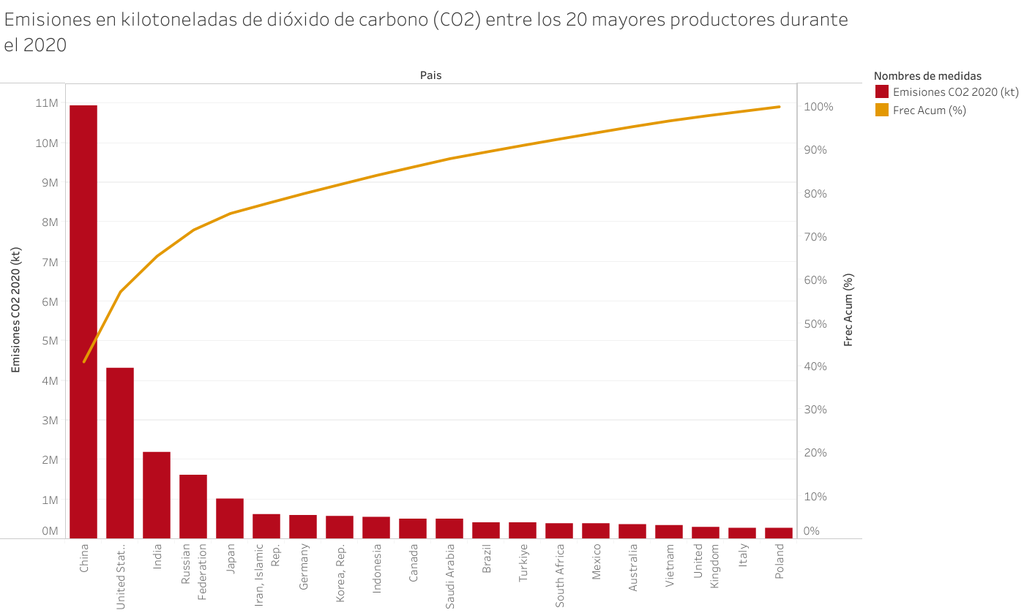

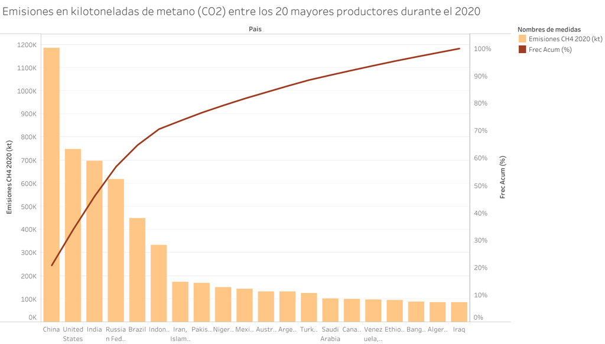

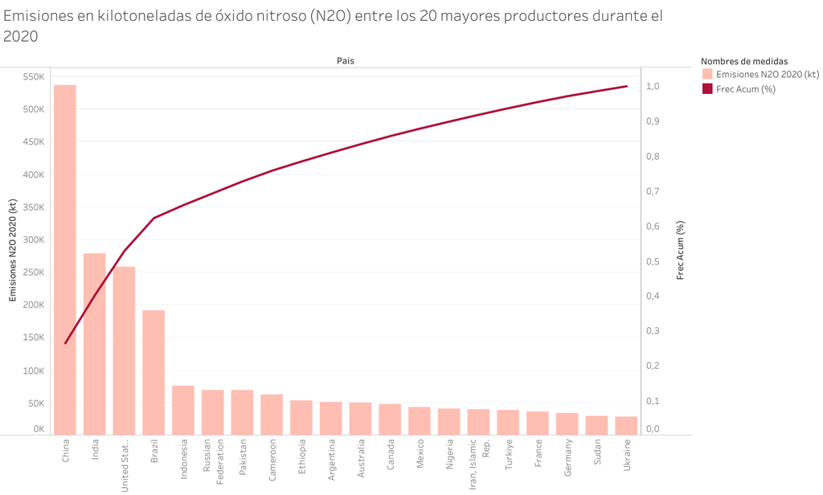

# Interpretación

# Conclusiones y caminos de acción

Aunque para este informe no hicimos un enfrentamiento entre emisiones de gases y PBI, podemos inferir con facilidad que son los países de mayor desarrollo y actividad industrial los que mayores emisiones de CO2 registran. Por lo pronto, con todas las limitaciones de este análisis, todo indica que el impacto medioambiental es indivisible del modelo económico.

Lo que nos dicen los datos es que la responsabilidad y el compromiso de revertir esta situación debe ser asumido por aquellas partes que más responsabilidad tienen en el severo problema medioambiental que enfrenta toda la humanidad

Ante este dilema resulta injusto que se le exijan sacrificios a aquellas porciones del mundo que no estan contribuyendo con el problema pero padecen las consecuencias.

Este análisis deja más preguntas que respuestas. Algunas son:

- ¿Estarán los principales países del mundo dispuestos a asumir responsabilidades frente al problema de la contaminación ambiental?
- ¿De ser necesario, estarán dispuestos los ciudadanos a ceder comodidades y despojarse del actual modelo de consumo?
- ¿Están el sistema económico y social de la humanidad listos para asumir los cambios eventuales para revertir la situación?

Dada la dimensión de la cuestión, no tenemos un alcance de acción directo, pero sí nos llevamos consciencia del dilema. Y con ello una gran responsabilidad para con el futuro.